# 02: SD line, GoA, Regression

## What we know so far

- *Correlation coefficient*: measure of **linear** association, or clustering about a line (which line?).

\[ r = \frac{\sum_{i=1}^n(x_i-\bar{x})(y_i-\bar{y})} {\sqrt{\sum_{i=1}^n (x_i-\bar{x})^2}\sqrt{\sum_{i=1}^n (y_i-\bar{y})^2}} \]

- *If* the scatterplot of both variables is a *football-shaped* cloud of points, we can *summarize* the relationship between both variables with:
  - average of x-values, SD of x-values,
  - average of y-values, SD of y-values.
  - the correlation coefficient r.

```r
(meanx <- mean(x))
```

```
## [1] 67.6871
```

```r
sd(x)
```

```
## [1] 2.744868
```

```r
(meany <- mean(y))
```

```
## [1] 68.68407
```

```r
sd(y)
```

```
## [1] 2.814702
```

```r
(r <- cor(x, y))
```

```
## [1] 0.5013383
```

## Which standard deviation?

- For simplicity, FPP uses, unless in the presence of a very small sample, SD instead of sd.
- SD is obtained by dividing by \(n\) instead of by \(n - 1\) (R has `sd` function for the latter, and no function for the former).

\[ \text{SD}_X=\sqrt{\frac{1}{n}\sum_{i=1}^n (X_i-\bar{X})^2} ~~~~~~ \text{sd}_X=\sqrt{\frac{1}{n-1}\sum_{i=1}^n (X_i-\bar{X})^2} \]

- The preferred one is sd, (as the associated sample variance \(\hat\sigma^2\) is an unbiased estimator of the population variance, while the other is biased).
- In the case of Pearson’s data (1,078) the difference by using SD instead of sd is:

```r
## FPP version of sample standard deviation
SD <- function(x) sqrt(mean((x-mean(x))^2))
```

- Difference (in inches) of using SD instead of sd:

```r
SD(x) - sd(x)
```

```
## [1] -0.001273425
```

```r
SD(y) - sd(y)
```

```
## [1] -0.001305823
```

which is negligible.

- Note: the *maximum likelihood* estimator of the variance also divides by \(n\) instead of \(n-1\), so it is biased (and used).
- Also, *both* SD and sd are biased estimators of \(\sigma\).
- We will illustrate both approaches, that lead mostly to the same *final* results, pointing out when they disagree.

## The SD line

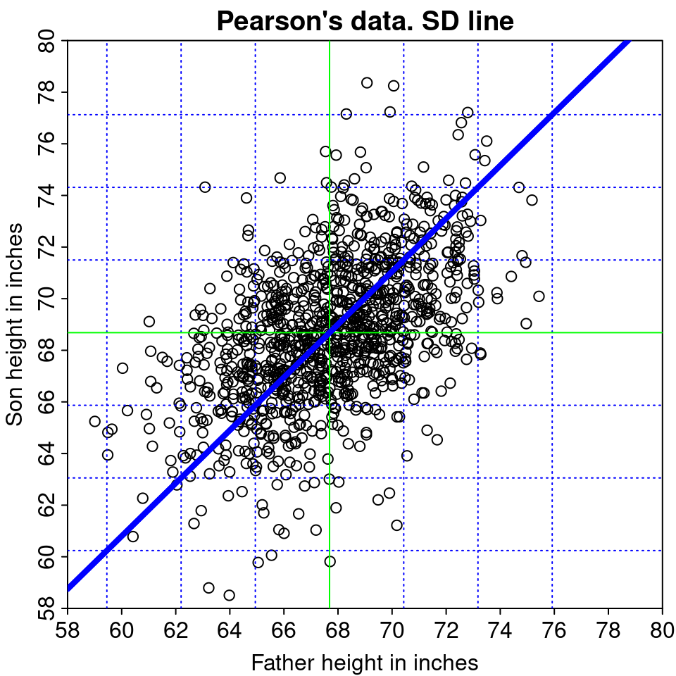

- Find the equation of the SD line, knowing that it passes throught two points:
  - \((\bar{x},\bar{y})\) and \((\bar{x}+\text{SD}_x,\bar{y}+\text{SD}_y)\) or
  - \((\bar{x},\bar{y})\) and \((\bar{x}+\text{sd}_x,\bar{y}+\text{sd}_y)\)
- The result should be: \[ y=\frac{\text{SD}_y}{\text{SD}_x} x+\bar{y}-\frac{\text{SD}_y}{\text{SD}_x}\bar{x} \] where \(\frac{\text{SD}_y}{\text{SD}_x}\) is the slope and \(\bar{y}-\frac{\text{SD}_y}{\text{SD}_x}\bar{x}\) is the intercept.
- Alternatively: \[ y=\frac{\text{sd}_y}{\text{sd}_x} x+\bar{y}-\frac{\text{sd}_y}{\text{sd}_x}\bar{x} \]

[output not shown]

[figure not shown]